# Portfolio_1: Cooking during Covid

Lindley Slipetz

2/12/2021

In this portfolio piece, we will look at how people’s relationship to cooking and baking has changed pre- and during Covid. There are four spreadsheets in this file. I’m leaving off the first sheet because it uses a different scale than the other sheets. Also, there is no documentation for this data, and it’s not exactly clear how the first sheet is measuring google trends. The final three are number of mentions of the activities on Twitter, Forums, and Blogs. Let’s load some data!

```r
library(readxl)
Cooking_Twitter_raw <- read_excel("G:/My Drive/DataScience/Covid/Cooking.xlsx", sheet = 2)
Cooking_Forums_raw <- read_excel("G:/My Drive/DataScience/Covid/Cooking.xlsx", sheet = 3)
Cooking_Blogs_raw <- read_excel("G:/My Drive/DataScience/Covid/Cooking.xlsx", sheet = 4)
library(tidyverse)
library(data.table)
```

This data is messy. Let’s make it tidy! I’m not going to even try to work within these dataframes because they’re just that messy. Let’s start by making a new dataframe! We’ll just get the columns together first and then we’ll add the data.

```r
cooking_columns <- c("Venue", "Timepoint", "Recipes", "Baking_Bread", "Sourdough", "Cooking_directions", "Cook")
cooking_data <- as.data.frame(matrix(ncol = length(cooking_columns), nrow=0, dimnames = list(NULL,cooking_columns)) )
```

Okay, time to add the data to the new dataframe.

```r
##Blog time 1
cooking_data <-rbind(cooking_data, data.frame(
   Venue = "Blog",
   Timepoint = 1,
   Recipes = Cooking_Blogs_raw$`Mentions before March 13 (January 3, 2020-March 12, 2020)...8`[Cooking_Blogs_raw$...7 == "Recipes" & is.na(Cooking_Blogs_raw$...7) == FALSE],
   Baking_Bread = Cooking_Blogs_raw$`Mentions before March 13 (January 3, 2020-March 12, 2020)...8`[Cooking_Blogs_raw$...7 == "Baking bread" & is.na(Cooking_Blogs_raw$...7) == FALSE],
   Sourdough = Cooking_Blogs_raw$`Mentions before March 13 (January 3, 2020-March 12, 2020)...8`[Cooking_Blogs_raw$...7 == "Sourdough" & is.na(Cooking_Blogs_raw$...7) == FALSE],
   Cooking_directions = Cooking_Blogs_raw$`Mentions before March 13 (January 3, 2020-March 12, 2020)...8`[Cooking_Blogs_raw$...7 == "Cooking Directions" & is.na(Cooking_Blogs_raw$...7) == FALSE],
   Cook = Cooking_Blogs_raw$`Mentions before March 13 (January 3, 2020-March 12, 2020)...8`[Cooking_Blogs_raw$...7 == "Cook" & is.na(Cooking_Blogs_raw$...7) == FALSE]))
##Blog time 2
cooking_data <-rbind(cooking_data, data.frame(
   Venue = "Blog",
   Timepoint = 2,
   Recipes = Cooking_Blogs_raw$`Mentions after March 13 (March 14, 2020-May 22, 2020)...10`[Cooking_Blogs_raw$...7 == "Recipes" & is.na(Cooking_Blogs_raw$...7) == FALSE],
   Baking_Bread = Cooking_Blogs_raw$`Mentions after March 13 (March 14, 2020-May 22, 2020)...10`[Cooking_Blogs_raw$...7 == "Baking bread" & is.na(Cooking_Blogs_raw$...7) == FALSE],
   Sourdough = Cooking_Blogs_raw$`Mentions after March 13 (March 14, 2020-May 22, 2020)...10`[Cooking_Blogs_raw$...7 == "Sourdough" & is.na(Cooking_Blogs_raw$...7) == FALSE],
   Cooking_directions = Cooking_Blogs_raw$`Mentions after March 13 (March 14, 2020-May 22, 2020)...10`[Cooking_Blogs_raw$...7 == "Cooking Directions" & is.na(Cooking_Blogs_raw$...7) == FALSE],
   Cook = Cooking_Blogs_raw$`Mentions after March 13 (March 14, 2020-May 22, 2020)...10`[Cooking_Blogs_raw$...7 == "Cook" & is.na(Cooking_Blogs_raw$...7) == FALSE]))
##Twitter time 1
cooking_data <-rbind(cooking_data, data.frame(
   Venue = "Twitter",
   Timepoint = 1,
 Recipes = Cooking_Twitter_raw$`Mentions before March 13 (January 3, 2020-March 12, 2020)...8`[Cooking_Twitter_raw$...7 == "Recipes" & is.na(Cooking_Twitter_raw$...7) == FALSE],
   Baking_Bread = Cooking_Twitter_raw$`Mentions before March 13 (January 3, 2020-March 12, 2020)...8`[Cooking_Twitter_raw$...7 == "Baking bread" & is.na(Cooking_Twitter_raw$...7) == FALSE],
   Sourdough = Cooking_Twitter_raw$`Mentions before March 13 (January 3, 2020-March 12, 2020)...8`[Cooking_Twitter_raw$...7 == "Sourdough" & is.na(Cooking_Twitter_raw$...7) == FALSE],
   Cooking_directions = Cooking_Twitter_raw$`Mentions before March 13 (January 3, 2020-March 12, 2020)...8`[Cooking_Twitter_raw$...7 == "Cooking Directions" & is.na(Cooking_Twitter_raw$...7) == FALSE],
   Cook = Cooking_Twitter_raw$`Mentions before March 13 (January 3, 2020-March 12, 2020)...8`[Cooking_Twitter_raw$...7 == "Cook" & is.na(Cooking_Twitter_raw$...7) == FALSE]))
##Twitter time 2
cooking_data <-rbind(cooking_data, data.frame(
   Venue = "Twitter",
   Timepoint = 2,
   Recipes = Cooking_Twitter_raw$`Mentions after March 13 (March 14, 2020-May 22, 2020)...10`[Cooking_Twitter_raw$...7 == "Recipes" & is.na(Cooking_Twitter_raw$...7) == FALSE],
   Baking_Bread = Cooking_Twitter_raw$`Mentions after March 13 (March 14, 2020-May 22, 2020)...10`[Cooking_Twitter_raw$...7 == "Baking bread" & is.na(Cooking_Twitter_raw$...7) == FALSE],
   Sourdough = Cooking_Twitter_raw$`Mentions after March 13 (March 14, 2020-May 22, 2020)...10`[Cooking_Twitter_raw$...7 == "Sourdough" & is.na(Cooking_Twitter_raw$...7) == FALSE],
   Cooking_directions = Cooking_Twitter_raw$`Mentions after March 13 (March 14, 2020-May 22, 2020)...10`[Cooking_Twitter_raw$...7 == "Cooking Directions" & is.na(Cooking_Twitter_raw$...7) == FALSE],
   Cook = Cooking_Twitter_raw$`Mentions after March 13 (March 14, 2020-May 22, 2020)...10`[Cooking_Twitter_raw$...7 == "Cook" & is.na(Cooking_Twitter_raw$...7) == FALSE]))
##Forums time 1
cooking_data <-rbind(cooking_data, data.frame(
   Venue = "Forums",
   Timepoint = 1,
 Recipes = Cooking_Forums_raw$`Mentions before March 13 (January 3, 2020-March 12, 2020)...8`[Cooking_Forums_raw$...7 == "Recipes" & is.na(Cooking_Forums_raw$...7) == FALSE],
   Baking_Bread = Cooking_Forums_raw$`Mentions before March 13 (January 3, 2020-March 12, 2020)...8`[Cooking_Forums_raw$...7 == "Baking bread" & is.na(Cooking_Forums_raw$...7) == FALSE],
   Sourdough = Cooking_Forums_raw$`Mentions before March 13 (January 3, 2020-March 12, 2020)...8`[Cooking_Forums_raw$...7 == "Sourdough" & is.na(Cooking_Forums_raw$...7) == FALSE],
   Cooking_directions = Cooking_Forums_raw$`Mentions before March 13 (January 3, 2020-March 12, 2020)...8`[Cooking_Forums_raw$...7 == "Cooking Directions" & is.na(Cooking_Forums_raw$...7) == FALSE],
   Cook = Cooking_Forums_raw$`Mentions before March 13 (January 3, 2020-March 12, 2020)...8`[Cooking_Forums_raw$...7 == "Cook" & is.na(Cooking_Forums_raw$...7) == FALSE]))
##Forums time 2
cooking_data <-rbind(cooking_data, data.frame(
   Venue = "Forums",
   Timepoint = 2,
   Recipes = Cooking_Forums_raw$`Mentions after March 13 (March 14, 2020-May 22, 2020)...10`[Cooking_Forums_raw$...7 == "Recipes" & is.na(Cooking_Forums_raw$...7) == FALSE],
   Baking_Bread = Cooking_Forums_raw$`Mentions after March 13 (March 14, 2020-May 22, 2020)...10`[Cooking_Forums_raw$...7 == "Baking bread" & is.na(Cooking_Forums_raw$...7) == FALSE],
   Sourdough = Cooking_Forums_raw$`Mentions after March 13 (March 14, 2020-May 22, 2020)...10`[Cooking_Forums_raw$...7 == "Sourdough" & is.na(Cooking_Forums_raw$...7) == FALSE],
   Cooking_directions = Cooking_Forums_raw$`Mentions after March 13 (March 14, 2020-May 22, 2020)...10`[Cooking_Forums_raw$...7 == "Cooking Directions" & is.na(Cooking_Forums_raw$...7) == FALSE],
   Cook = Cooking_Forums_raw$`Mentions after March 13 (March 14, 2020-May 22, 2020)...10`[Cooking_Forums_raw$...7 == "Cook" & is.na(Cooking_Forums_raw$...7) == FALSE]))
```

Phew, now we have a tidy dataframe. Let’s take a look at it.

```r
glimpse(cooking_data)
```

```
## Observations: 6
## Variables: 7
## $ Venue              <fct> Blog, Blog, Twitter, Twitter, Forums, Forums
## $ Timepoint          <dbl> 1, 2, 1, 2, 1, 2
## $ Recipes            <fct> 2291.2571428571428, 2862.7, 7332.9857142857145, ...
## $ Baking_Bread       <fct> 81.242857142857147, 224.58571428571429, 403.3, 1...
## $ Sourdough          <fct> 93.142857142857139, 278.37142857142857, 605.2999...
## $ Cooking_directions <fct> 10.1, 14.5, 7.9571428571428573, 26.4857142857142...
## $ Cook               <fct> 3211.0571428571429, 4019.1285714285714, 43583.84...
```

Well, that didn’t really tell us much. Let’s look at the descriptives grouped by time point. First, our observations are factors at the moment, so let’s fix that.

```r
cooking_data$Recipes <- as.numeric(as.character(cooking_data$Recipes))
cooking_data$Baking_Bread <- as.numeric(as.character(cooking_data$Baking_Bread))
cooking_data$Sourdough <- as.numeric(as.character(cooking_data$Sourdough))
cooking_data$Cooking_directions <- as.numeric(as.character(cooking_data$Cooking_directions))
cooking_data$Cook <- as.numeric(as.character(cooking_data$Cook))
```

Okay, now we can look at the means.

```r
cooking_mean <- setDT(cooking_data)
cooking_mean[, .(Recipes = mean(Recipes), Baking_Bread = mean(Baking_Bread), Sourdough = mean(Sourdough), Cooking_directions = mean(Cooking_directions), Cook = mean(Cook)), by = .(Timepoint)]
```

```
##    Timepoint  Recipes Baking_Bread Sourdough Cooking_directions     Cook
## 1:         1 4108.557     197.4905  388.2714           7.414286 18096.60
## 2:         2 8532.081     781.0000 1715.6857          16.909524 24815.22
```

Notice that the means across venues increase across time, but we don’t know if that change is statistically significant. Let’s do some paired sample t-tests. We’re testing the hypothesis that time 1 mentions (pre-Covid) are significantly less than time 2 mentions (during-Covid).

```r
t_Recipe <- t.test(Recipes ~ Timepoint, data = cooking_data, paired = TRUE, alternative = "less")
t_Recipe
```

```
##
##  Paired t-test
##
## data:  Recipes by Timepoint
## t = -1.9876, df = 2, p-value = 0.0926
## alternative hypothesis: true difference in means is less than 0
## 95 percent confidence interval:
##      -Inf 2075.137
## sample estimates:
## mean of the differences
##               -4423.524
```

```r
t_Bread <- t.test(Baking_Bread ~ Timepoint, data = cooking_data, paired = TRUE, alternative = "less")
t_Bread
```

```
##
##  Paired t-test
##
## data:  Baking_Bread by Timepoint
## t = -1.3803, df = 2, p-value = 0.1508
## alternative hypothesis: true difference in means is less than 0
## 95 percent confidence interval:
##      -Inf 650.9208
## sample estimates:
## mean of the differences
##               -583.5095
```

```r
t_Sourdough <- t.test(Sourdough ~ Timepoint, data = cooking_data, paired = TRUE, alternative = "less")
t_Sourdough
```

```
##
##  Paired t-test
##
## data:  Sourdough by Timepoint
## t = -1.7288, df = 2, p-value = 0.113
## alternative hypothesis: true difference in means is less than 0
## 95 percent confidence interval:
##     -Inf 914.564
## sample estimates:
## mean of the differences
##               -1327.414
```

```r
t_Directions <- t.test(Cooking_directions ~ Timepoint, data = cooking_data, paired = TRUE, alternative = "less")
t_Directions
```

```
##
##  Paired t-test
##
## data:  Cooking_directions by Timepoint
## t = -2.0965, df = 2, p-value = 0.08549
## alternative hypothesis: true difference in means is less than 0
## 95 percent confidence interval:
##      -Inf 3.729383
## sample estimates:
## mean of the differences
##               -9.495238
```

```r
t_Cook <- t.test(Cook ~ Timepoint, data = cooking_data, paired = TRUE, alternative = "less")
t_Cook
```

```
##
##  Paired t-test
##
## data:  Cook by Timepoint
## t = -1.2097, df = 2, p-value = 0.175
## alternative hypothesis: true difference in means is less than 0
## 95 percent confidence interval:
##      -Inf 9499.301
## sample estimates:
## mean of the differences
##               -6718.619
```

Well, it looks like mentions of cooking-related topics during Covid aren’t significantly greater than mentions of cooking-related topics pre-Covid. While the media has reported the trend in cooking during Covid, people don’t mention it on Twitter, Blogs, or Forums a statistically greater amount than before.

Oh well, let’s do some graphs anyway. I tried to do a facet wrap by column (e.g., “Baking_Bread” and “Cook”), but the scales differ so drastically among the columns that I don’t think that’s the best way to go about it. Also, there’s a lot of info I’m trying to cram into every graph, so it seems best to seperate them.

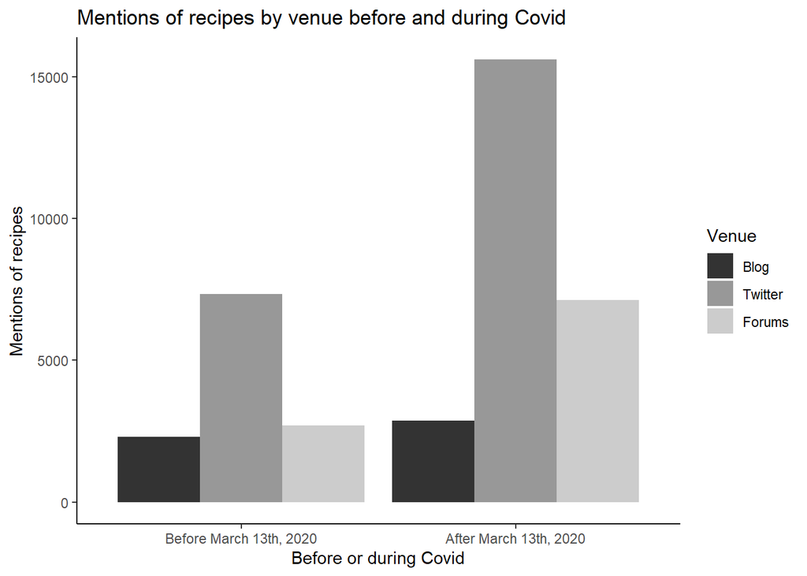

```r
cooking_data %>%
    ggplot(aes(x = Timepoint,y = Recipes, fill = Venue)) +
    geom_bar(stat = "identity",position = "dodge") +
    scale_fill_grey() + theme_classic() +
    scale_x_discrete("Before or during Covid", labels = c("Before March 13th, 2020", "After March 13th, 2020"), limits = c(1, 2)) +
    labs(title = "Mentions of recipes by venue before and during Covid",
         y = "Mentions of recipes")
```

We can see with the recipe data that Blog mentions barely increased but Twitter mentions approximately doubled. Now let’s look at Baking Bread!

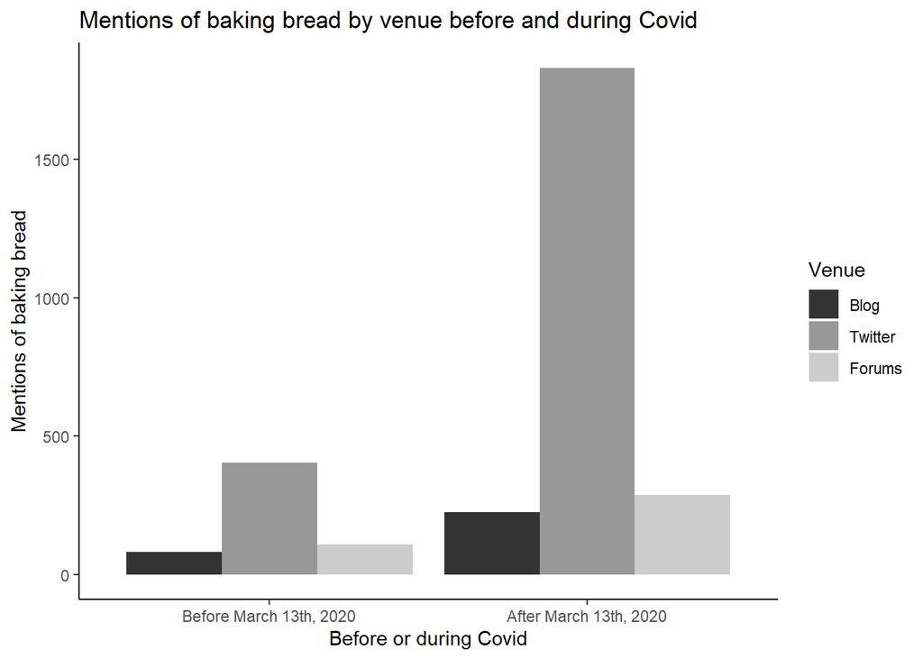

```r
cooking_data %>%
    ggplot(aes(x = Timepoint,y = Baking_Bread, fill = Venue)) +
    geom_bar(stat = "identity",position = "dodge") +
    scale_fill_grey() + theme_classic() +
    scale_x_discrete("Before or during Covid", labels = c("Before March 13th, 2020", "After March 13th, 2020"), limits = c(1, 2)) +
    labs(title = "Mentions of baking bread by venue before and during Covid",
         y = "Mentions of baking bread")
```

With the baking bread data, again we see a huge leap in Twitter mentions. It’s making me think we should look more at the Twitter data…but let’s keep going with our graphs.

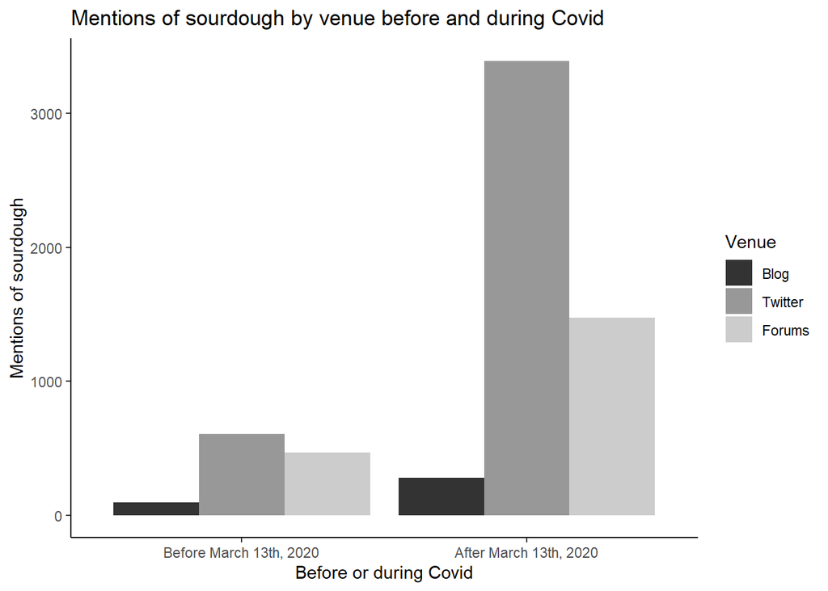

```r
cooking_data %>%
    ggplot(aes(x = Timepoint,y = Sourdough, fill = Venue)) +
    geom_bar(stat = "identity",position = "dodge") +
    scale_fill_grey() + theme_classic() +
    scale_x_discrete("Before or during Covid", labels = c("Before March 13th, 2020", "After March 13th, 2020"), limits = c(1, 2)) +
    labs(title = "Mentions of sourdough by venue before and during Covid",
         y = "Mentions of sourdough")
```

Sourdough also shows a huge difference in mentions like the previous data. This is lending more evidence that there might be something going on with the Twitter data.

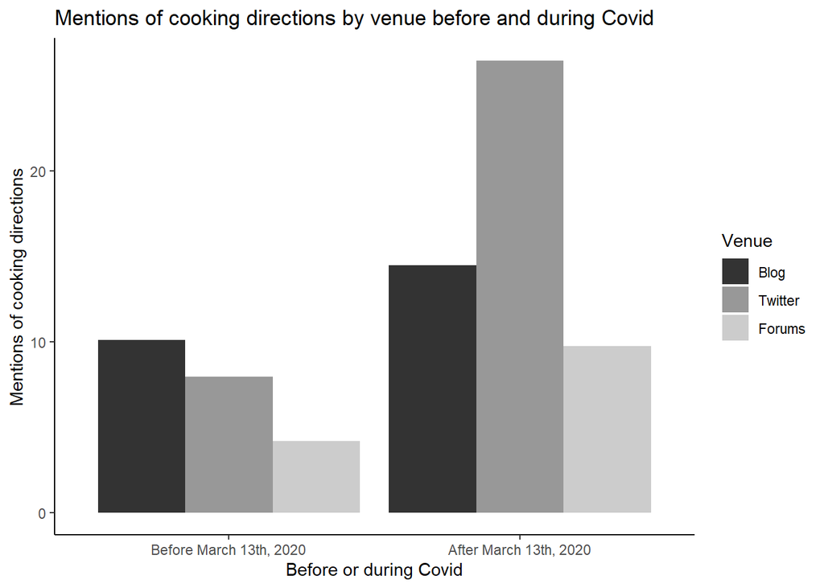

```r
cooking_data %>%
    ggplot(aes(x = Timepoint,y = Cooking_directions, fill = Venue)) +
    geom_bar(stat = "identity",position = "dodge") +
    scale_fill_grey() + theme_classic() +
    scale_x_discrete("Before or during Covid", labels = c("Before March 13th, 2020", "After March 13th, 2020"), limits = c(1, 2)) +
    labs(title = "Mentions of cooking directions by venue before and during Covid",
         y = "Mentions of cooking directions")
```

There’s a difference for the Twitter data again for cooking directions, but notice the difference in the scale between this data and the previous graphs. Does this smaller difference help support a statistically significant difference pre- and during Covid?

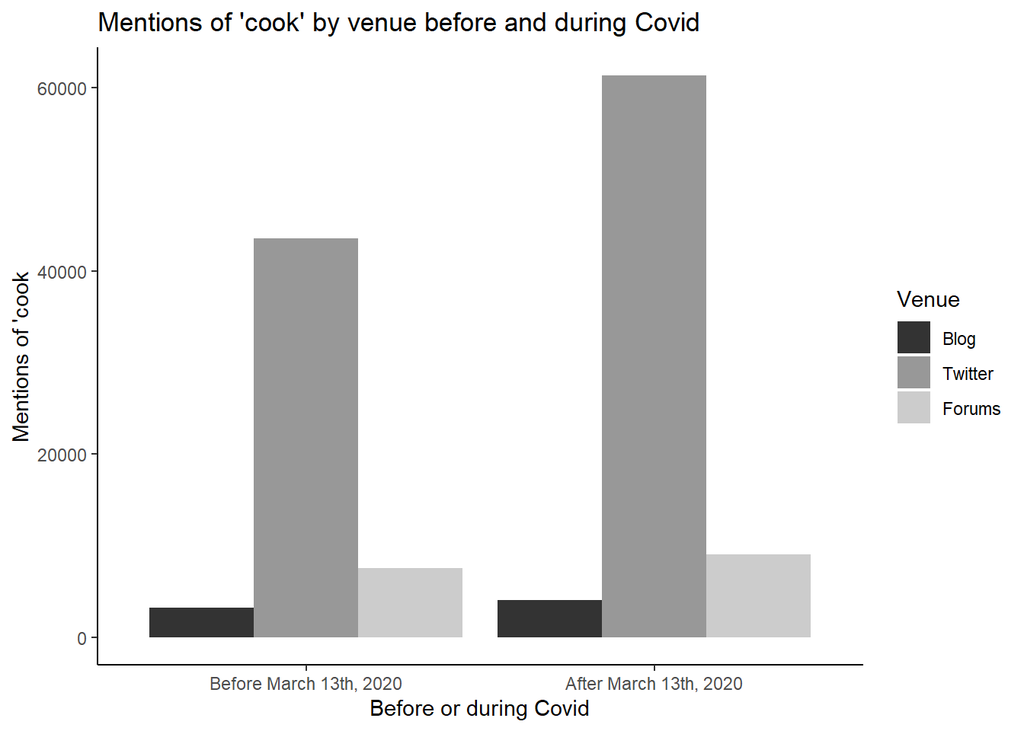

```r
cooking_data %>%
    ggplot(aes(x = Timepoint,y = Cook, fill = Venue)) +
    geom_bar(stat = "identity",position = "dodge") +
    scale_fill_grey() + theme_classic() +
    scale_x_discrete("Before or during Covid", labels = c("Before March 13th, 2020", "After March 13th, 2020"), limits = c(1, 2)) +
    labs(title = "Mentions of 'cook' by venue before and during Covid",
         y = "Mentions of 'cook")
```

The graph shows us that there was, again, a large leap in mentions of ‘cook.’ I think we should revisit the t-test, this time limiting to just twitter and see if there’s a significant difference.

```r
Twitter <- cooking_data %>%
  filter(Venue == "Twitter") %>%
  gather(Type, value, Recipes, Baking_Bread, Sourdough, Cooking_directions,
  Cook, na.rm = FALSE, convert = FALSE)
t_Twitter <- t.test(value ~ Timepoint, data = Twitter, paired = TRUE, alternative = "less")
t_Twitter
```

```
##
##  Paired t-test
##
## data:  value by Timepoint
## t = -1.864, df = 4, p-value = 0.06788
## alternative hypothesis: true difference in means is less than 0
## 95 percent confidence interval:
##      -Inf 871.6265
## sample estimates:
## mean of the differences
##               -6066.963
```

Well, it wasn’t significant, but it was close. So what have we found…

The media has reported that there has been an increase in interest in cooking/baking activities since Covid started. We looked at if there were a significant increase in mentions across platforms (Twitter, Blog, Forum). Although the graphs show there are differences, t-tests demonstrated that the differences are not significant.